# Homework 3

seyma cakir

12/13/2021

```r
# Libraries imported.
library(data.table)
library(ggplot2)
library(tidyr)
require(dplyr)
require(rpart)
require(caret)
library(tidyverse)
require(TSrepr)
require(TSdist)
require(dtw)
require(TunePareto)
library(zoo)
```

```r
#The environment set as HW3 folder to get dataset eaisly and write files easily.
setwd('D:\\Users\\seyma\\Documents\\GitHub\\fall21-seymacakir\\HW3')
#To avoid randomness in evey run of code, the set.seed function used.
set.seed(488)
```

# Homerwork 3

**Task: Comparison of NN classifiers with Alternative Representations.**

The aim of this task is to compare alternative distance measures for classification. For that purpose 5 different datasets from [Time series Classification](http://www.timeseriesclassification.com) are used which are Trace, ECG200, PowerCons, SmoothSubspace,and Plane. The Datasets represented by two different representation technique which are Piecewise Linear Approximation divide data linear regression models by points and Rpart regression tree. The parameter of PLA which important point is tried for two diffenert value and the maxdepth parameter of regression tree is also tried for two different value. The four different distance calculation methods used: Euclidian distance, DTW, LCSS, and ERP. Based on distance calculation the classes predicted by k-nn classifier for 1,3 and 5. The results evaluated by using Cross-Validation Technique which divide data to 10 fold and use one fold as test data. The process is repeated for 5 times, and test dat selected such as include equal rate of classes with train data. In the end, the average accuracy values and standart deviation calculated for each method, and selected the best method. The selected method used for predict actual test data.

## Functions

The functions are created for the repeated processes.

```r
##############################################

raw_data_preperation <- function(data){

  # data readed
  train_data <-  as.data.table( read.table(sprintf("%s\\%s_TRAIN.txt",data,data)))
  test_data <- as.data.table( read.table(sprintf("%s\\%s_TEST.txt",data,data)))
  # change V1 column since it represents classes
  setnames(train_data,'V1','class')
  setnames(test_data,'V1','class')
  train_data$class = as.factor(train_data$class)
  # assign ID for each time series.
  train_data[,id:=1:.N]
  print(head(train_data))

  #first column is the class variable
  trainclass=train_data$class
  testclass=test_data$class
  dist_path = sprintf("%s/%s/distances", getwd(),data)

  data <- list(traindata = train_data[,2:(ncol(train_data)-1)], # Take only observation values
               testdata = test_data[,2:(ncol(test_data)-1)],
               trainclass = trainclass,
               testclass =testclass,
               distpath = dist_path,
               raw_data = train_data)

  return(data)

}
###########################################################

# function for show the structure of time series classifications.
g1 <- function(data,dataset){

long_train=melt(data,id.vars=c('id','class'))
long_train[,time:=as.numeric(gsub("\\D", "", variable))-1]
long_train=long_train[,list(id,class,time,value)]
ggplot(long_train, aes(time,value)) + geom_line(aes(color=as.character(id))) +
      labs(
          title = sprintf(" %s Time Series by Classes", dataset)
          ) +
   theme_classic() +  theme(legend.position = "none") +
    facet_wrap(~class)


}


############################################################

# Piecewise linear approximation
# based on *Zhu Y, Wu D, Li Sh (2007) A Piecewise Linear Representation Method of Time Series
# Based on Feature Points. Knowledge-Based Intelligent Information and Engineering Systems 4693:1066-1072*

pla_rep_data <- function(dataset,n_important,raw_data){

  # Data involves id and class variables
  train_data <- raw_data
  # Data involves only time series observations
  traindata <- train_data[,2:(ncol(train_data)-1)]
  trainclass <- train_data$class
  # melt the data for long format
  long_train=melt(train_data,id.vars=c('id','class'))
  # using gsub to set the nonnumerical part to zero length
  long_train[,time:=as.numeric(gsub("\\D", "", variable))-1]
  # remove variable
  long_train=long_train[,list(id,class,time,value)]
  long_train=long_train[order(id,time)]

  for (i in 1:nrow(train_data)){
    # select series to represent
    data=long_train[id==i]
    data_ts <- data$value
    # set parameter and represent as PLA
    pla_rep=repr_pla(data_ts, times = n_important, return = "both")
    # fill the blanks between points and add time
    setnames(pla_rep,c('places','points'),c('time','pla_rep'))
    pla_rep$time=pla_rep$time+1
    data=merge(data,pla_rep,by='time',all.x=T)
    data[, pla_rep := na.approx(pla_rep)]
    # change real observations with representation values
    traindata[i] <- as.data.table(t(data$pla_rep))
    }
  data <- list(traindata = traindata)
  return(data)
}

#########################################################################

# Regression trees recuresively partitions the predictor space to obtain piecewise constant models

rpart_rep_data <- function(dataset,maxdepth, raw_data){
  # Data involves id and class variables
  train_data <- raw_data
  # Data involves only time series observations to change with representations
  traindata <- train_data[,2:(ncol(train_data)-1)]
  trainclass <- train_data$class
  # melt the data for long format
  long_train=melt(train_data,id.vars=c('id','class'))
  # using gsub to set the nonnumerical part to zero length
  long_train[,time:=as.numeric(gsub("\\D", "", variable))-1]
  # remove variable
  long_train=long_train[,list(id,class,time,value)]
  long_train=long_train[order(id,time)]

    for (i in 1:nrow(traindata)){
    # select the data for representation
    data=long_train[id==i]
    # set parameters and represent data
    tree_fit=rpart(value~time,data,control=rpart.control(maxdepth=maxdepth))
    data[,tree_rep:=predict(tree_fit,data)]
    # change actual variables with representation
    traindata[i] <- as.data.table(t(data$tree_rep))
    }

  data <- list(traindata = traindata)
  return(data)
}



########################################################################

# Create a function calculates distances and record them with data set name, representation model info, and distance approach

# This function calculte distances and record them as csv files to read when the distances matirx used so in the code they are run one times and commented to avoid calculaton every time code runs to calculate again.
#the comment sign "#" should deleted.

get_distances = function(traindata,dist_path,dataset,rep) {

# calculate distances and store them to save time
large_number=100000000000000000000

# Euclidean Distance
dist_euc=as.matrix(dist(traindata))
diag(dist_euc)=large_number
fwrite(dist_euc,sprintf('%s/%s_euc_%s.csv',dist_path,dataset,rep),col.names=F)

# DTW method
dist_dtw=as.matrix(dtwDist(traindata))
diag(dist_dtw)=large_number
fwrite(dist_dtw,sprintf('%s/%s_dtw_%s.csv',dist_path,dataset,rep),col.names=F)

# LCSS method
dist_lcss=TSDatabaseDistances(traindata,distance='lcss',epsilon=0.05)
dist_lcss=as.matrix(dist_lcss)
diag(dist_lcss)=large_number
fwrite(dist_lcss,sprintf('%s/%s_lcss_%s.csv',dist_path,dataset,rep),col.names=F)

# ERP merhod
dist_erp=TSDatabaseDistances(traindata,distance='erp',g=0.5)
dist_erp=as.matrix(dist_erp)
diag(dist_erp)=large_number
fwrite(dist_erp,sprintf('%s/%s_erp_%s.csv',dist_path,dataset,rep),col.names=F)

}

#######################################################################################

# classification used k-nn approach
nn_classify_cv=function(dist_matrix,train_class,test_indices,k=1){

    test_distances_to_train=dist_matrix[test_indices,]
    test_distances_to_train=test_distances_to_train[,-test_indices]
    train_class=train_class[-test_indices]

    ordered_indices=apply(test_distances_to_train,1,order)
    if(k==1){
        nearest_class=as.numeric(train_class[as.numeric(ordered_indices[1,])])
        nearest_class=data.table(id=test_indices,nearest_class)
    } else {
        nearest_class=apply(ordered_indices[1:k,],2,function(x) {train_class[x]})
        nearest_class=data.table(id=test_indices,t(nearest_class))
    }

    long_nn_class=melt(nearest_class,'id')

    class_counts=long_nn_class[,.N,list(id,value)]
    class_counts[,predicted_prob:=N/k]
    wide_class_prob_predictions=dcast(class_counts,id~value,value.var='predicted_prob')
    wide_class_prob_predictions[is.na(wide_class_prob_predictions)]=0
    class_predictions=class_counts[,list(predicted=value[which.max(N)]),by=list(id)]


    return(list(prediction=class_predictions,prob_estimates=wide_class_prob_predictions))

}

###################################################################################

# Calculation of accuarcy by using cross-validation technique

get_acc = function(dist_path,nof_rep = 5,n_fold = 10, k_levels, trainclass){
dist_files=list.files(dist_path, full.names=T)

cv_indices=generateCVRuns(trainclass, ntimes =nof_rep, nfold = n_fold,
                          leaveOneOut = FALSE, stratified = TRUE)

approach_file=list.files(dist_path)
result=vector('list',length(dist_files)*nof_rep*n_fold*length(k_levels))
iter=1
for(m in 1:length(dist_files)){
      dist_mat=as.matrix(fread(dist_files[m],header=FALSE))
    for(i in 1:nof_rep){
        this_fold=cv_indices[[i]]
        for(j in 1:n_fold){
            test_indices=this_fold[[j]]
            for(k in 1:length(k_levels)){
                current_k=k_levels[k]
                current_fold=nn_classify_cv(dist_mat,trainclass,test_indices,k=current_k)
                accuracy=sum(trainclass[test_indices]==current_fold$prediction$predicted)/length(test_indices)
                tmp=data.table(dataset = strsplit(approach_file[m],"_")[[1]][1],
                               rep = strsplit(approach_file[m],"_")[[1]][3],
                               approach= strsplit(approach_file[m],"_")[[1]][2],
                               repid=i,
                               foldid=j,
                               k=current_k,
                               acc=accuracy)
                result[[iter]]=tmp
                iter=iter+1

            }

        }

    }

}
return (list(result))
}


######################################################

# representation of accuracy values

show_results <- function( get_acc, Dataset){
  results =rbindlist(get_acc[[1]])
  overall_results <- results[,list(avg_acc=mean(acc),sdev_acc=sd(acc),result_count=.N),by=list(dataset,rep,approach,k)]
# The results shown by box plot

  g <- ggplot(results,aes(x=paste0(approach,'-', rep,"-",k), y=acc)) +
        geom_boxplot() + labs(
             title = sprintf(" Accuracies of %s Dataset", Dataset),
            x = "Methods",
            y = "Accuracy") + theme_minimal() +  coord_flip()
  print(g)


  max <- overall_results[avg_acc == max(overall_results$avg_acc)]
  results <- as.data.table(overall_results[order(avg_acc)])

  return(list(max, results))

}
```

## Dataset 1: Trace

The first data set used is Trace Dataset from [Time series Classification](http://www.timeseriesclassification.com/description.php?Dataset=Trace)

The Time series Classification Web site summarize data as:

“This 4-class dataset is a subset of the Transient Classification Benchmark (trace project), an initiative at the turn of the century to collate data from the application domain of the process industry (e.g. nuclear, chemical, etc.). It is a synthetic dataset designed to simulate instrumentation failures in a nuclear power plant, created by Davide Roverso. The full dataset consists of 16 classes, 50 instances in each class. Each instance has 4 features. The TRACE subset only uses the second feature of class 2 and the third feature of class 3 and 7. Hence, this dataset contains 200 instances, 50 for each class. All instances are linearly interpolated to have the same length of 275 data points, and are z-normalized.”

The example of data shown below. Data is proceed to first column indicates class and last column indicates id of time series. Other columns from V2 to V276 shows the observations during the time.

```r
### TRACE DATA SET ###
# the data pre-proceed
Trace_raw_data <- raw_data_preperation("Trace")
```

```
##    class         V2         V3         V4         V5         V6         V7
## 1:     1  0.5440704  0.6578630  0.6112391  0.5454131  0.5321561  0.5930125
## 2:     2  0.7664298  0.6246319  0.7422470  0.6682216  0.7661175  0.7306850
## 3:     4 -2.0450118 -2.0916771 -2.0776367 -2.0335167 -1.9901730 -2.0577092
## 4:     3 -1.7050221 -1.7391240 -1.7256591 -1.8017184 -1.7425432 -1.7603664
## 5:     1  0.5413721  0.5719079  0.5621467  0.5209509  0.5274937  0.6040431
## 6:     4 -1.2781808 -1.2707170 -1.2754118 -1.2440114 -1.2965360 -1.2243645
##            V8         V9        V10        V11        V12        V13        V14
## 1:  0.5952802  0.5382770  0.5634290  0.5959565  0.6329149  0.5846464  0.6231872
## 2:  0.6551092  0.7293299  0.7236512  0.7028178  0.7561677  0.7004173  0.6823094
## 3: -2.0128429 -2.0509702 -2.0553157 -2.0760096 -1.9999803 -2.0131392 -2.0493882
## 4: -1.6915715 -1.6875198 -1.7615121 -1.7748398 -1.7821487 -1.7649892 -1.7377334
## 5:  0.5405210  0.5803829  0.5005821  0.5978125  0.5553183  0.5039982  0.4872150
## 6: -1.2484483 -1.2160164 -1.2532291 -1.2904419 -1.2262962 -1.2746380 -1.2482585
##           V15        V16        V17        V18        V19        V20        V21
```

[output cut: 272 more lines]

```r
# distances of raw data time series are  calculated
#get_distances(Trace_raw_data$traindata,Trace_raw_data$distpath, "Trace","raw")
```

The graph below shows the time series by classes.

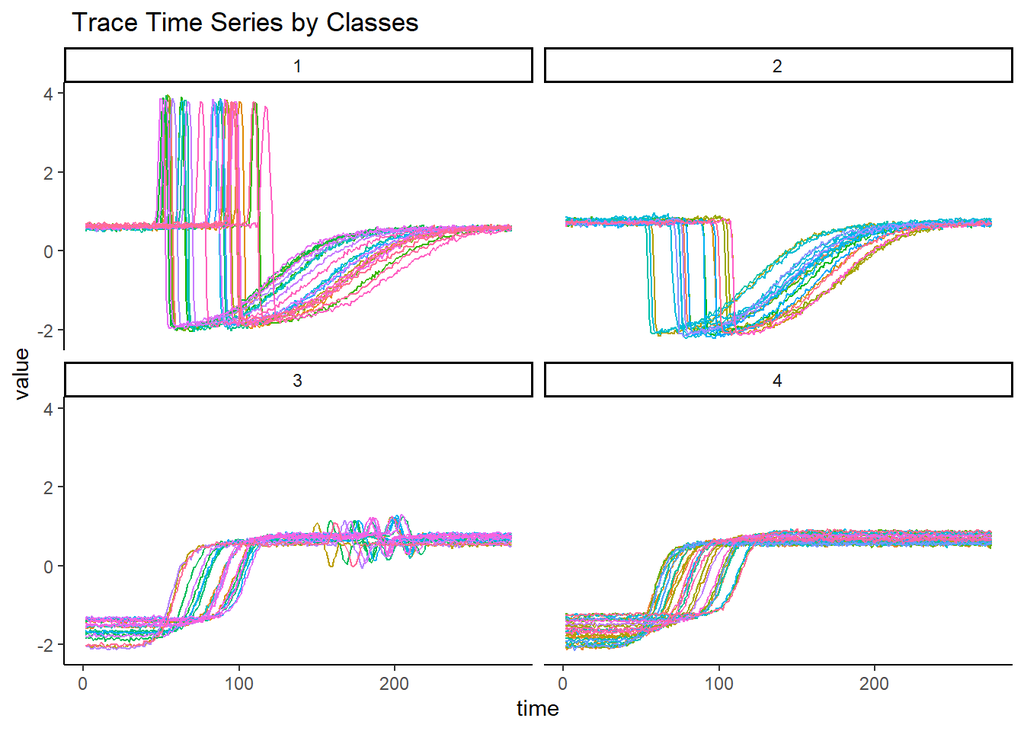

```r
g1(Trace_raw_data$raw_data, "Trace")
```

### Classification with Time Series Representation

**Piece Linear Approximation method set points parameter = 3**

```r
# Data representation and preparation
Trace_pla_rep_3 <- pla_rep_data("Trace",3 ,Trace_raw_data$raw_data)
# Distance Calculated
#get_distances(Trace_pla_rep_3$traindata,Trace_raw_data$distpath,"Trace","PLApoints3")
```

**Piece Linear Approximation method set points parameter = 5**

```r
# Data representation and preparation
Trace_pla_rep_5 <- pla_rep_data("Trace", 5,Trace_raw_data$raw_data)
# Distance Calculated
#get_distances(Trace_pla_rep_5$traindata, Trace_raw_data$distpath,"Trace","PLApoints5")
```

**Rpart Representation set max depth parameter = 3**

```r
# Data representation and preparation
Trace_rpart_3 <- rpart_rep_data("Trace", 3 ,Trace_raw_data$raw_data)
# Distance calculated
#get_distances(Trace_rpart_3$traindata,Trace_raw_data$distpath,"Trace","Rpartmaxdepth3")
```

**Rpart Representation set max depth parameter = 5**

```r
# Data representation and preparation
Trace_rpart_5 <- rpart_rep_data("Trace", 5, Trace_raw_data$raw_data)
# Distance Calculated
#get_distances(Trace_rpart_5$traindata,Trace_raw_data$distpath,"Trace","Rpartmaxdepth5")
```

### Results of Methods

The Accuracy Values calculted and shown below.

```r
Trace_Results <- get_acc(Trace_raw_data$distpath,5,10,c(1,3,5),Trace_raw_data$trainclass)
TRACE <- show_results(Trace_Results,"Trace")
```

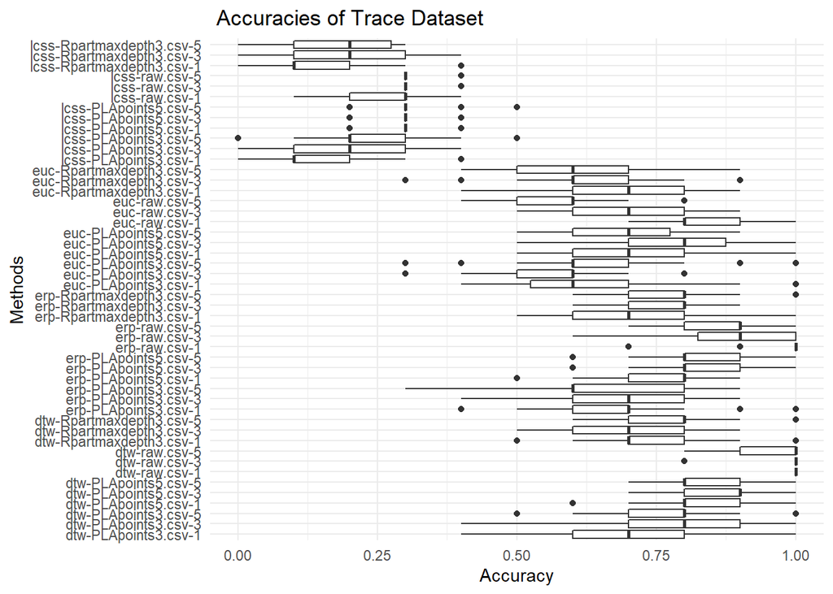

```r
TRACE[[2]]
```

```
##     dataset                rep approach k avg_acc   sdev_acc result_count
##  1:   Trace Rpartmaxdepth3.csv     lcss 1   0.140 0.11248583           50
##  2:   Trace     PLApoints3.csv     lcss 1   0.156 0.10528872           50
##  3:   Trace Rpartmaxdepth3.csv     lcss 5   0.178 0.09538322           50
##  4:   Trace Rpartmaxdepth3.csv     lcss 3   0.184 0.10567567           50
##  5:   Trace     PLApoints3.csv     lcss 3   0.200 0.11428571           50
##  6:   Trace     PLApoints3.csv     lcss 5   0.240 0.12777531           50
##  7:   Trace            raw.csv     lcss 1   0.256 0.06114553           50
##  8:   Trace     PLApoints5.csv     lcss 1   0.298 0.04280950           50
##  9:   Trace     PLApoints5.csv     lcss 3   0.300 0.05345225           50
## 10:   Trace     PLApoints5.csv     lcss 5   0.302 0.06848208           50
## 11:   Trace            raw.csv     lcss 3   0.310 0.03030458           50
## 12:   Trace            raw.csv     lcss 5   0.310 0.03030458           50
## 13:   Trace     PLApoints3.csv      euc 3   0.582 0.13044664           50
## 14:   Trace            raw.csv      euc 5   0.584 0.07655863           50
```

[output cut: 35 more lines]

### Prediction of Dataset Trace

The dtw distance calculation with 1-nn classifier method gives the accuracy value 1 which is the best accuracy based on raw data time series, the predictions made with this method.

```r
# The data readed and merge to predict test data by train data without use test.

Trace_train_data <- as.data.table( read.table("Trace\\Trace_TRAIN.txt"))
dim(Trace_train_data)
```

```
## [1] 100 276
```

```r
Trace_test_data <- as.data.table( read.table("Trace\\Trace_TEST.txt"))
dim(Trace_test_data)
```

```
## [1] 100 276
```

```r
Trace_data <- rbind(Trace_train_data,Trace_test_data)
dim(Trace_data)
```

```
## [1] 200 276
```

```r
Trace_data[,id := 1:.N]

Trace_matrix <- Trace_data[, 2:(ncol(Trace_data)-1)]
Trace_class <- as.factor(Trace_data$V1)

#distance matrix calculted with dtw method.
#dist_dtw=as.matrix(dtwDist(Trace_matrix))
#diag(dist_dtw)= 2*max(dist_dtw)
#fwrite(dist_dtw,'Trace/TEST.csv',col.names=F)

dist_matrix <-as.matrix(fread("D:\\Users\\seyma\\Documents\\GitHub\\fall21-seymacakir\\HW3\\Trace\\TEST.csv",header=FALSE))

# predictions basen on 1-nn classifier
Trace_TEST_prediction <- as.factor(nn_classify_cv(dist_matrix,Trace_class,test_indices = c(101:200), k=1)$prediction$predicted)

# the confusion matrix of predictions shown.
confusionMatrix(data = Trace_TEST_prediction, reference = Trace_class[101:200])
```

```
## Confusion Matrix and Statistics
##
##           Reference
## Prediction  1  2  3  4
##          1 24  0  0  0
##          2  0 29  0  0
##          3  0  0 27  0
##          4  0  0  1 19
##
## Overall Statistics
##
##                Accuracy : 0.99
##                  95% CI : (0.9455, 0.9997)
##     No Information Rate : 0.29
##     P-Value [Acc > NIR] : < 2.2e-16
##
##                   Kappa : 0.9866
##
##  Mcnemar's Test P-Value : NA
##
## Statistics by Class:
##
##                      Class: 1 Class: 2 Class: 3 Class: 4
## Sensitivity              1.00     1.00   0.9643   1.0000
## Specificity              1.00     1.00   1.0000   0.9877
## Pos Pred Value           1.00     1.00   1.0000   0.9500
## Neg Pred Value           1.00     1.00   0.9863   1.0000
## Prevalence               0.24     0.29   0.2800   0.1900
## Detection Rate           0.24     0.29   0.2700   0.1900
## Detection Prevalence     0.24     0.29   0.2700   0.2000
## Balanced Accuracy        1.00     1.00   0.9821   0.9938
```

```r
Trace_test_acc <- confusionMatrix(data = Trace_TEST_prediction, reference = Trace_class[101:200])$overall["Accuracy"]
```

The accuracy value is 0.99 in test data, which is very close train data results.

## Dataset 2 : ECG200

The dataset ECG200 used is provided by [Time Series Classification Website](http://www.timeseriesclassification.com/description.php?Dataset=ECG200) explains dataset as:

This dataset was formatted by R. Olszewski as part of his thesis “Generalized feature extraction for structural pattern recognition in time-series data” at Carnegie Mellon University, 2001. Each series traces the electrical activity recorded during one heartbeat. The two classes are a normal heartbeat and a Myocardial Infarction.

The example of data shown below. Data is proceed to first column indicates class and last column indicates id of time series. Other columns shows the observations during the time.

```r
### ECG200 DATA SET ###
# the data pre-proceed
ECG200_raw_data <- raw_data_preperation("ECG200")
```

```
##    class        V2        V3        V4        V5         V6         V7
## 1:    -1 0.5020555 0.5421626 0.7223835 1.4288852 2.13651580  2.2811490
## 2:     1 0.1476469 0.8046684 0.3677715 0.2438937 0.02661388 -0.2744021
## 3:    -1 0.3166462 0.2431991 0.3704714 1.0637381 1.67818710  1.7595575
## 4:    -1 1.1688741 2.0759008 1.7601405 1.6064459 1.94904560  1.3028421
## 5:     1 0.6486575 0.7520260 2.6362312 3.4557156 2.11815740  0.5206202
## 6:     1 0.4047327 1.2808587 2.5151479 1.2995187 1.45343230  0.4742751
##             V8         V9        V10        V11         V12        V13
## 1:  1.93627370  1.4688900  1.0088451  0.3802822 -0.29677967 -0.5139287
## 2:  0.09673058 -0.7477306 -1.6097771 -1.1795931 -1.05592640 -1.1287774
## 3:  1.69771720  1.6121590  1.1681877  0.4999570 -0.02236253 -0.2353182
## 4:  0.45933154  0.5164121  0.8521795  0.9892272  0.82125349  0.5764476
## 5: -0.18862656  0.7808184  0.9337747  0.7014020  1.00613300  0.3957838
## 6: -1.39656190 -0.6470808  0.4319451  0.1324451 -0.40660902  0.2305663
##           V14         V15        V16        V17         V18        V19
```

[output cut: 97 more lines]

```r
# distances calculated
#get_distances(ECG200_raw_data$traindata,ECG200_raw_data$distpath, "ECG200","raw")
```

The graph below shows the time series by classes.

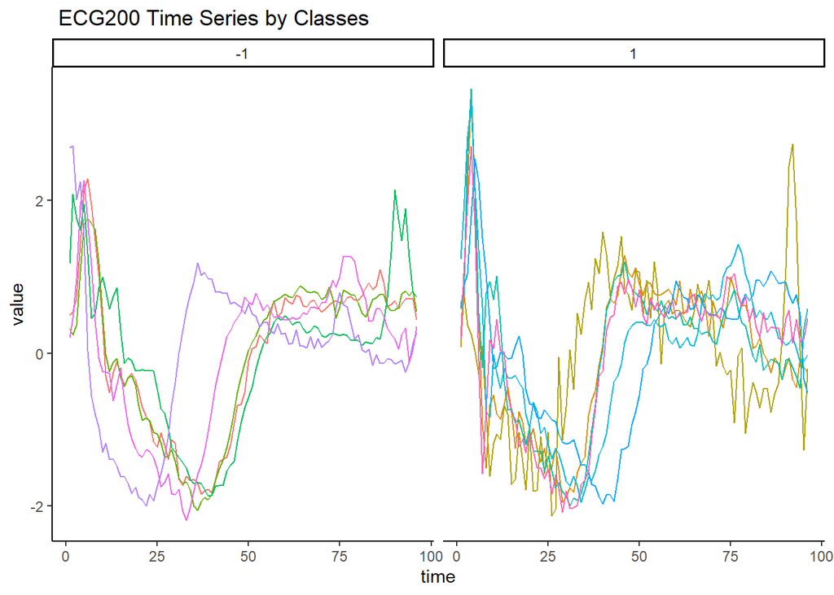

```r
g1(ECG200_raw_data$raw_data[c(1:5,95:100),], "ECG200")
```

### Classification with Time Series Representation

**Piece Linear Approximation method set points parameter = 5**

```r
# Data representation and preparation
ECG200_pla_rep_5 <- pla_rep_data("ECG200",5 ,ECG200_raw_data$raw_data)
# Distance Calculated
#get_distances(ECG200_pla_rep_5$traindata,ECG200_raw_data$distpath,"ECG200","PLApoints5")
```

**Piece Linear Approximation method set points parameter = 10**

```r
# Data representation and preparation
ECG200_pla_rep_10 <- pla_rep_data("ECG200", 10,ECG200_raw_data$raw_data)
# Distance Calculated
#get_distances(ECG200_pla_rep_10$traindata, ECG200_raw_data$distpath,"ECG200","PLApoints10")
```

**Rpart Regression Tree method set maxdepth parameter = 5**

```r
# Data representation and preparation
ECG200_rpart_5 <- rpart_rep_data("ECG200", 5 ,ECG200_raw_data$raw_data)
# Distance calculated
#get_distances(ECG200_rpart_5$traindata,ECG200_raw_data$distpath,"ECG200","Rpartmaxdepth5")
```

**Rpart Regression Tree method set maxdepth parameter = 10**

```r
# Data representation and preparation
ECG200_rpart_10 <- rpart_rep_data("ECG200", 10, ECG200_raw_data$raw_data)
# Distance Calculated
#get_distances(ECG200_rpart_10$traindata,ECG200_raw_data$distpath,"ECG200","Rpartmaxdepth10")
```

### Results of Methods

The Accuracy Values calculted and shown below.

```r
ECG200_Results <- get_acc(ECG200_raw_data$distpath,5,10,c(1,3,5),ECG200_raw_data$trainclass)
ECG200 <- show_results(ECG200_Results,"ECG200")
```

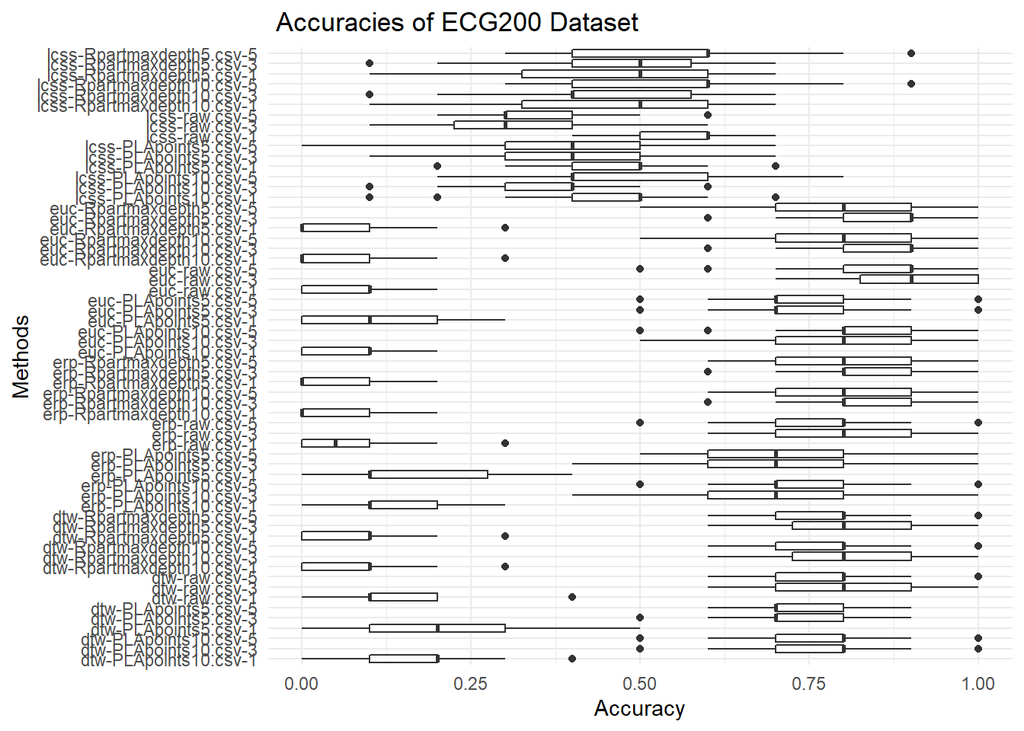

```r
ECG200[[2]]
```

```
##     dataset                 rep approach k avg_acc   sdev_acc result_count
##  1:  ECG200 Rpartmaxdepth10.csv      euc 1   0.052 0.07351246           50
##  2:  ECG200  Rpartmaxdepth5.csv      euc 1   0.052 0.07351246           50
##  3:  ECG200 Rpartmaxdepth10.csv      erp 1   0.060 0.06998542           50
##  4:  ECG200  Rpartmaxdepth5.csv      erp 1   0.060 0.06998542           50
##  5:  ECG200             raw.csv      erp 1   0.062 0.07253430           50
##  6:  ECG200             raw.csv      euc 1   0.070 0.06776309           50
##  7:  ECG200     PLApoints10.csv      euc 1   0.080 0.07824608           50
##  8:  ECG200 Rpartmaxdepth10.csv      dtw 1   0.088 0.08241260           50
##  9:  ECG200  Rpartmaxdepth5.csv      dtw 1   0.088 0.08241260           50
## 10:  ECG200      PLApoints5.csv      euc 1   0.110 0.09313146           50
## 11:  ECG200             raw.csv      dtw 1   0.114 0.08083745           50
## 12:  ECG200     PLApoints10.csv      erp 1   0.140 0.08571429           50
## 13:  ECG200      PLApoints5.csv      erp 1   0.150 0.11649647           50
## 14:  ECG200     PLApoints10.csv      dtw 1   0.160 0.10101525           50
```

[output cut: 47 more lines]

### Predicton of Dataset 2: ECG200

The Eucludaian distance method with raw data and k=3 nn claasifer give the best result with accuracy value 0.904 and std 0.09 based on raw data time series so, in prediction this method used.

```r
# data readed and merge to use train data as predictor of TEST data
ECG_train_data <- as.data.table( read.table("ECG200\\ECG200_TRAIN.txt"))
dim(ECG_train_data)
```

```
## [1] 100  97
```

```r
ECG_test_data <- as.data.table( read.table("ECG200\\ECG200_TEST.txt"))
dim(ECG_test_data)
```

```
## [1] 100  97
```

```r
ECG_data <- rbind(ECG_train_data,ECG_test_data)
ECG_data[,id := 1:.N]
dim(ECG_data)
```

```
## [1] 200  98
```

```r
ECG_matrix <- ECG_data[, 2:(ncol(ECG_data)-1)]
ECG_class <- as.factor(ECG_data$V1)

# Euclidiean diatnce calculated.
#dist_mat=as.matrix(dist(ECG_matrix))
#diag(dist_mat)=  2*max(dist_mat)
#fwrite(dist_mat,'ECG200/distances/TEST.csv',col.names=F)

dist_matrix <-as.matrix(fread("D:\\Users\\seyma\\Documents\\GitHub\\fall21-seymacakir\\HW3\\ECG200\\TEST.csv",header=FALSE))

# predictions with 3-nn classifier.
ECG_TEST_prediction <- as.factor(nn_classify_cv(dist_matrix,ECG_class,test_indices = c(101:200), k=3)$prediction$predicted)

# Confusion Matrix shown
confusionMatrix(data = ECG_TEST_prediction, reference = ECG_class[101:200])
```

```
## Confusion Matrix and Statistics
##
##           Reference
## Prediction -1  1
##         -1 29  3
##         1   7 61
##
##                Accuracy : 0.9
##                  95% CI : (0.8238, 0.951)
##     No Information Rate : 0.64
##     P-Value [Acc > NIR] : 2.814e-09
##
##                   Kappa : 0.7776
##
##  Mcnemar's Test P-Value : 0.3428
##
##             Sensitivity : 0.8056
##             Specificity : 0.9531
##          Pos Pred Value : 0.9063
##          Neg Pred Value : 0.8971
##              Prevalence : 0.3600
##          Detection Rate : 0.2900
##    Detection Prevalence : 0.3200
##       Balanced Accuracy : 0.8793
##
##        'Positive' Class : -1
##
```

```r
ECG_test_acc = confusionMatrix(data = ECG_TEST_prediction, reference = ECG_class[101:200])$overall["Accuracy"]
```

The test data results very close train data results.

## Dataset 3: Plane

The Dataset 3 Plane is provided by Time Series Classification Website

The data shows 7 different type of plane image as time series data and data is normalized. The Class of data shown below by 1-7 as a-g:

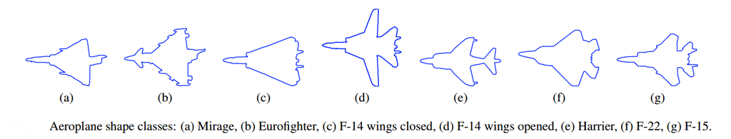

Type of Planes

The example of data shown below. Data is proceed to first column indicates class and last column indicates id of time series. Other columns shows the observations during the time.

```r
### Plane DATA SET ###
# the data pre-proceed
Plane_raw_data <- raw_data_preperation("Plane")
```

```
##    class       V2        V3        V4        V5        V6          V7
## 1:     1 2.483940 2.2762865 2.0675157 1.9218926 1.7187752  1.50842850
## 2:     4 2.603320 2.3406991 2.0822848 1.8256242 1.5677057  1.31220300
## 3:     6 2.757321 2.5766667 2.3633233 2.1515785 1.9402183  1.72942750
## 4:     5 0.916063 0.7201453 0.5224446 0.3258262 0.1343814 -0.05401188
## 5:     2 2.656142 2.3881447 2.1185954 1.8496769 1.5765789  1.31016860
## 6:     6 2.716798 2.5208585 2.3196204 2.1164411 1.9136371  1.71124980
##            V8         V9        V10        V11         V12        V13
## 1:  1.3006752  1.0902862  0.8827328  0.6723009  0.46338263  0.2545249
## 2:  1.0571948  0.8017157  0.5466832  0.2918485  0.03662012 -0.0761458
## 3:  1.5194285  1.3095473  1.1002525  0.8914930  0.68316216  0.4828424
## 4: -0.2355249 -0.4096045 -0.5744532 -0.7823530 -1.00531810 -1.2279865
## 5:  1.1096989  0.9309980  0.7506683  0.5393333  0.28010942  0.2027687
## 6:  1.5093279  1.3046473  1.1036170  0.8995841  0.69586494  0.5034464
##            V14        V15         V16        V17        V18        V19
```

[output cut: 153 more lines]

```r
# distances calculated
#get_distances(Plane_raw_data$traindata,Plane_raw_data$distpath, "Plane","raw")
```

The graph below shows the time series by classes.

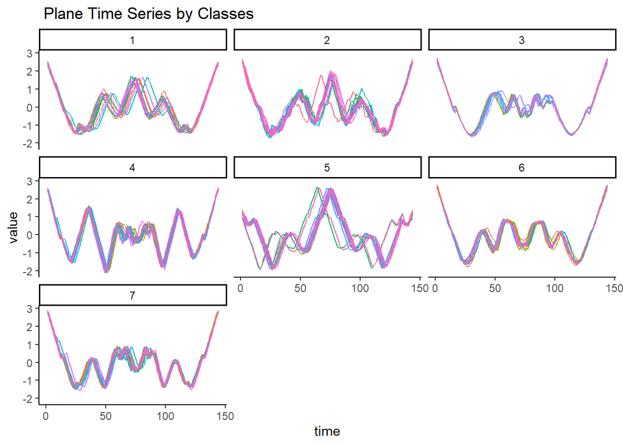

```r
g1(Plane_raw_data$raw_data, "Plane")
```

### Classification with Time Series Representation

**Piece Linear Approximation method set points parameter = 5**

```r
# Data representation and preparation
Plane_pla_rep_5 <- pla_rep_data("Plane",5 ,Plane_raw_data$raw_data)
# Distance Calculated
#(Plane_pla_rep_5$traindata,Plane_raw_data$distpath,"Plane","PLApoints5")
```

**Piece Linear Approximation method set points parameter = 10**

```r
# Data representation and preparation
Plane_pla_rep_10 <- pla_rep_data("Plane", 10,Plane_raw_data$raw_data)
# Distance Calculated
#get_distances(Plane_pla_rep_10$traindata, Plane_raw_data$distpath,"Plane","PLApoints10")
```

**Rpart Regression Tree Representation set max depth paramater = 5**

```r
# Data representation and preparation
Plane_rpart_5 <- rpart_rep_data("Plane", 5 ,Plane_raw_data$raw_data)
# Distance calculated
#get_distances(Plane_rpart_5$traindata,Plane_raw_data$distpath,"Plane","Rpartmaxdepth5")
```

**Rpart Regression Tree Representation set max depth paramater = 10**

```r
# Data representation and preparation
Plane_rpart_10 <- rpart_rep_data("Plane", 10, Plane_raw_data$raw_data)
# Distance Calculated
#get_distances(Plane_rpart_10$traindata,Plane_raw_data$distpath,"Plane","Rpartmaxdepth10")
```

### Results of Methods

```r
Plane_Results <- get_acc(Plane_raw_data$distpath,5,10,c(1,3,5),Plane_raw_data$trainclass)
PLANE <- show_results(Plane_Results,"Plane")
```

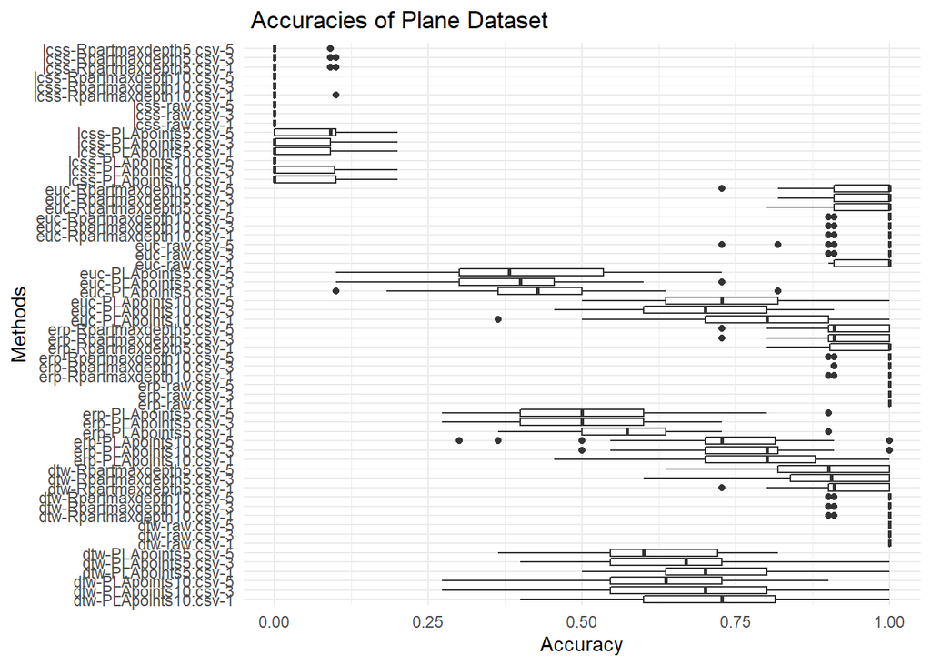

```r
PLANE[[2]]
```

```
##     dataset                 rep approach k     avg_acc   sdev_acc result_count
##  1:   Plane     PLApoints10.csv     lcss 5 0.000000000 0.00000000           50
##  2:   Plane             raw.csv     lcss 1 0.000000000 0.00000000           50
##  3:   Plane             raw.csv     lcss 3 0.000000000 0.00000000           50
##  4:   Plane             raw.csv     lcss 5 0.000000000 0.00000000           50
##  5:   Plane Rpartmaxdepth10.csv     lcss 3 0.000000000 0.00000000           50
##  6:   Plane Rpartmaxdepth10.csv     lcss 5 0.000000000 0.00000000           50
##  7:   Plane  Rpartmaxdepth5.csv     lcss 5 0.007272727 0.02491341           50
##  8:   Plane Rpartmaxdepth10.csv     lcss 1 0.010000000 0.03030458           50
##  9:   Plane  Rpartmaxdepth5.csv     lcss 3 0.011090909 0.03036240           50
## 10:   Plane  Rpartmaxdepth5.csv     lcss 1 0.020727273 0.03947881           50
## 11:   Plane      PLApoints5.csv     lcss 3 0.038909091 0.05604133           50
## 12:   Plane      PLApoints5.csv     lcss 1 0.044363636 0.05641927           50
## 13:   Plane     PLApoints10.csv     lcss 3 0.044909091 0.06929299           50
## 14:   Plane     PLApoints10.csv     lcss 1 0.056727273 0.06902839           50
```

[output cut: 47 more lines]

### Prediction of Datse 3: Plane

The dtw and erp method gives the best result which equals 1 in all classifiers 1,3,5 with raw data time series.

The predictions based on ERP 3-nn classifiers.

```r
# data readed and merge to use train data as predictor of TEST data
PLANE_train_data <- as.data.table( read.table("Plane\\Plane_TRAIN.txt"))
dim(PLANE_train_data)
```

```
## [1] 105 145
```

```r
PLANE_test_data <- as.data.table( read.table("PLANE\\Plane_TEST.txt"))
dim(PLANE_test_data)
```

```
## [1] 105 145
```

```r
PLANE_data <- rbind(PLANE_train_data,PLANE_test_data)
PLANE_data[,id := 1:.N]
dim(PLANE_data)
```

```
## [1] 210 146
```

```r
PLANE_matrix <- PLANE_data[, 2:(ncol(PLANE_data)-1)]
PLANE_class <- as.factor(PLANE_data$V1)

# distances calcultes with erp method
#dist_mat=as.matrix(TSDatabaseDistances(PLANE_matrix,distance='erp',g=0.5))
#diag(dist_mat)=  2*max(dist_mat)
#fwrite(dist_mat,'PLANE/TEST.csv',col.names=F)

dist_matrix <-as.matrix(fread("D:\\Users\\seyma\\Documents\\GitHub\\fall21-seymacakir\\HW3\\Plane\\TEST.csv",header=FALSE))

# Predcitions made with 3-nn classifier
PLANE_TEST_prediction <- as.factor(nn_classify_cv(dist_matrix,PLANE_class,test_indices = c(106:210), k=3)$prediction$predicted)

# confusion matrix

confusionMatrix(data = PLANE_TEST_prediction, reference = PLANE_class[106:210])
```

```
## Confusion Matrix and Statistics
##
##           Reference
## Prediction  1  2  3  4  5  6  7
##          1 15  1  0  0  0  0  0
##          2  0 15  0  0  0  0  0
##          3  0  0 21  0  0  0  0
##          4  0  0  0 14  0  0  0
##          5  0  0  0  0 17  0  0
##          6  0  0  0  0  0 12  0
##          7  0  0  0  0  0  0 10
##
## Overall Statistics
##
##                Accuracy : 0.9905
##                  95% CI : (0.9481, 0.9998)
##     No Information Rate : 0.2
##     P-Value [Acc > NIR] : < 2.2e-16
##
##                   Kappa : 0.9888
##
##  Mcnemar's Test P-Value : NA
##
## Statistics by Class:
##
##                      Class: 1 Class: 2 Class: 3 Class: 4 Class: 5 Class: 6
## Sensitivity            1.0000   0.9375      1.0   1.0000   1.0000   1.0000
## Specificity            0.9889   1.0000      1.0   1.0000   1.0000   1.0000
## Pos Pred Value         0.9375   1.0000      1.0   1.0000   1.0000   1.0000
## Neg Pred Value         1.0000   0.9889      1.0   1.0000   1.0000   1.0000
## Prevalence             0.1429   0.1524      0.2   0.1333   0.1619   0.1143
## Detection Rate         0.1429   0.1429      0.2   0.1333   0.1619   0.1143
## Detection Prevalence   0.1524   0.1429      0.2   0.1333   0.1619   0.1143
## Balanced Accuracy      0.9944   0.9688      1.0   1.0000   1.0000   1.0000
##                      Class: 7
## Sensitivity           1.00000
## Specificity           1.00000
## Pos Pred Value        1.00000
## Neg Pred Value        1.00000
## Prevalence            0.09524
## Detection Rate        0.09524
## Detection Prevalence  0.09524
## Balanced Accuracy     1.00000
```

```r
confusionMatrix(data = PLANE_TEST_prediction, reference = PLANE_class[106:210])
```

```
## Confusion Matrix and Statistics
##
##           Reference
## Prediction  1  2  3  4  5  6  7
##          1 15  1  0  0  0  0  0
##          2  0 15  0  0  0  0  0
##          3  0  0 21  0  0  0  0
##          4  0  0  0 14  0  0  0
##          5  0  0  0  0 17  0  0
##          6  0  0  0  0  0 12  0
##          7  0  0  0  0  0  0 10
##
## Overall Statistics
##
##                Accuracy : 0.9905
##                  95% CI : (0.9481, 0.9998)
##     No Information Rate : 0.2
##     P-Value [Acc > NIR] : < 2.2e-16
##
##                   Kappa : 0.9888
##
##  Mcnemar's Test P-Value : NA
##
## Statistics by Class:
##
##                      Class: 1 Class: 2 Class: 3 Class: 4 Class: 5 Class: 6
## Sensitivity            1.0000   0.9375      1.0   1.0000   1.0000   1.0000
## Specificity            0.9889   1.0000      1.0   1.0000   1.0000   1.0000
## Pos Pred Value         0.9375   1.0000      1.0   1.0000   1.0000   1.0000
## Neg Pred Value         1.0000   0.9889      1.0   1.0000   1.0000   1.0000
## Prevalence             0.1429   0.1524      0.2   0.1333   0.1619   0.1143
## Detection Rate         0.1429   0.1429      0.2   0.1333   0.1619   0.1143
## Detection Prevalence   0.1524   0.1429      0.2   0.1333   0.1619   0.1143
## Balanced Accuracy      0.9944   0.9688      1.0   1.0000   1.0000   1.0000
##                      Class: 7
## Sensitivity           1.00000
## Specificity           1.00000
## Pos Pred Value        1.00000
## Neg Pred Value        1.00000
## Prevalence            0.09524
## Detection Rate        0.09524
## Detection Prevalence  0.09524
## Balanced Accuracy     1.00000
```

```r
Plane_test_acc <- confusionMatrix(data = PLANE_TEST_prediction, reference = PLANE_class[106:210])$overall["Accuracy"]
```

## Dataset 4: SmoothSubspace

The dataset 4 SmoothSubspace is provided by [Time Series Classification Website](http://www.timeseriesclassification.com/description.php?Dataset=SmoothSubspace) explained dataset as:

The data was originally intended for testing whether a clustering algorithm is able to extract smooth subspaces for clustering time series data [1]. There are 3 classes corresponding to which cluster the time series belong to. Each time series contain a continuous subspace spanning over 5 continuous time stamps. - For cluster 1, it is from time stamp 1-5 - For cluster 2, it is from time stamp 6-10 - For cluster 3, it is from time stamp 11-15. The rest of the time series are randomly generated. Data created by Xiaohui Huang et al. (see [1]). Data edited by Hoang Anh Dau. [1] Huang, Xiaohui, et al. “Time series k-means: A new k-means type smooth subspace clustering for time series data.” Information Sciences 367 (2016): 1-13.

The example of data shown below. Data is proceed to first column indicates class and last column indicates id of time series. Other columns shows the observations during the time.

```r
### SmoothSubspace DATA SET ###
# the data pre-proceed
SmoothSubspace_raw_data <- raw_data_preperation("SmoothSubspace")
```

```
##    class        V2        V3        V4        V5        V6        V7        V8
## 1:     1 0.4810517 0.6145143 0.6183783 0.4971101 0.6595241 0.8790139 0.6628081
## 2:     1 0.5175792 0.6477515 0.7577292 0.5509700 0.5986248 0.3185243 0.3985895
## 3:     1 0.4174242 0.6100467 0.7901224 0.5250664 0.5976593 0.4424023 0.1925104
## 4:     1 0.6322746 0.6261523 0.7710858 0.4517133 0.6186154 0.5605595 0.8541000
## 5:     1 0.4941312 0.6011924 0.7280025 0.4112070 0.5811399 0.7487057 0.7855590
## 6:     1 0.5128905 0.5825645 0.7455101 0.4872114 0.6074090 0.5340641 0.1339313
##           V9       V10        V11        V12        V13        V14        V15
## 1: 0.3288142 0.4023883 0.38724543 0.04265986 0.04229780 0.41704745 0.42791092
## 2: 0.1278884 0.7032232 0.81614010 0.99615611 0.24090500 0.93713467 0.43618496
## 3: 0.1966582 0.7580993 0.09851874 0.53566419 0.39000491 0.07068434 0.67477647
## 4: 0.1320830 0.1704320 0.35507365 0.69378761 0.48959434 0.66693153 0.61280959
## 5: 0.6078659 0.2175633 0.64206083 0.51181992 0.04755467 0.64630196 0.07103708
## 6: 0.5495401 0.5557379 0.31742786 0.35453430 0.71504501 0.82953282 0.82662951
##           V16 id
## 1: 0.42485841  1
## 2: 0.57892349  2
## 3: 0.05597616  3
## 4: 0.26013019  4
## 5: 0.68006553  5
## 6: 0.86688705  6
```

```r
# distances calculated
#get_distances(SmoothSubspace_raw_data$traindata,SmoothSubspace_raw_data$distpath, "SmoothSubspace","raw")
```

The graph below shows the time series by classes.

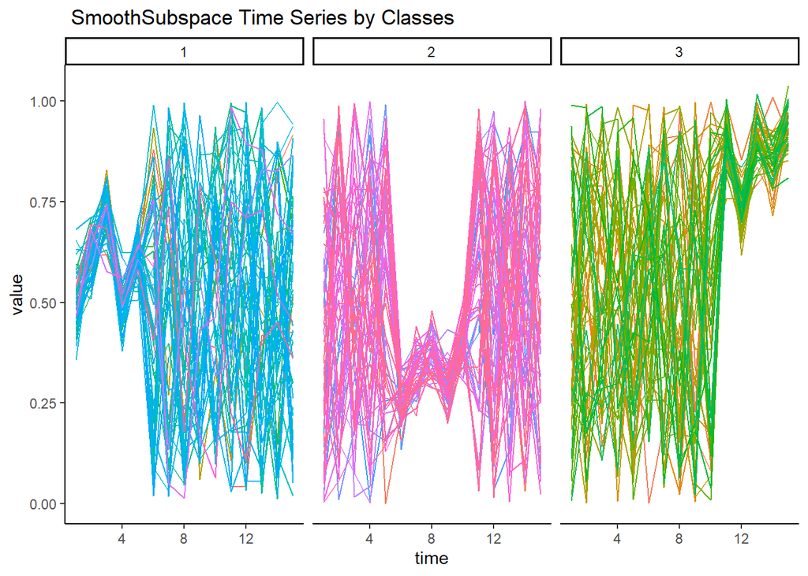

```r
g1(SmoothSubspace_raw_data$raw_data, "SmoothSubspace")
```

### Classification with Time Series Representation

**Piece Linear Approximation method set points parameter = 5**

```r
# Data representation and preparation
SmoothSubspace_pla_rep_5 <- pla_rep_data("SmoothSubspace",5 ,SmoothSubspace_raw_data$raw_data)
# Distance Calculated
#get_distances(SmoothSubspace_pla_rep_5$traindata,SmoothSubspace_raw_data$distpath,"SmoothSubspace","PLApoints5")
```

**Piece Linear Approximation method set points parameter = 10**

```r
# Data representation and preparation
SmoothSubspace_pla_rep_10 <- pla_rep_data("SmoothSubspace", 10,SmoothSubspace_raw_data$raw_data)
# Distance Calculated
#get_distances(SmoothSubspace_pla_rep_10$traindata, SmoothSubspace_raw_data$distpath,"SmoothSubspace","PLApoints10")
```

**Rpart Regression Tree Representation set max depth paramater = 5**

```r
# Data representation and preparation
SmoothSubspace_rpart_5 <- rpart_rep_data("SmoothSubspace", 5 ,SmoothSubspace_raw_data$raw_data)
# Distance calculated
#get_distances(SmoothSubspace_rpart_5$traindata,SmoothSubspace_raw_data$distpath,"SmoothSubspace","Rpartmaxdepth5")
```

**Rpart Regression Tree Representation set max depth paramater = 10**

```r
# Data representation and preparation
SmoothSubspace_rpart_10 <- rpart_rep_data("SmoothSubspace", 10, SmoothSubspace_raw_data$raw_data)
# Distance Calculated
#get_distances(SmoothSubspace_rpart_10$traindata,SmoothSubspace_raw_data$distpath,"SmoothSubspace","Rpartmaxdepth10")
```

### Results of Methods

```r
SmoothSubspace_Results <- get_acc(SmoothSubspace_raw_data$distpath,5,10,c(1,3,5),SmoothSubspace_raw_data$trainclass)
SMOOTHSUBSPACE <- show_results(SmoothSubspace_Results,"SmoothSubspace")
```

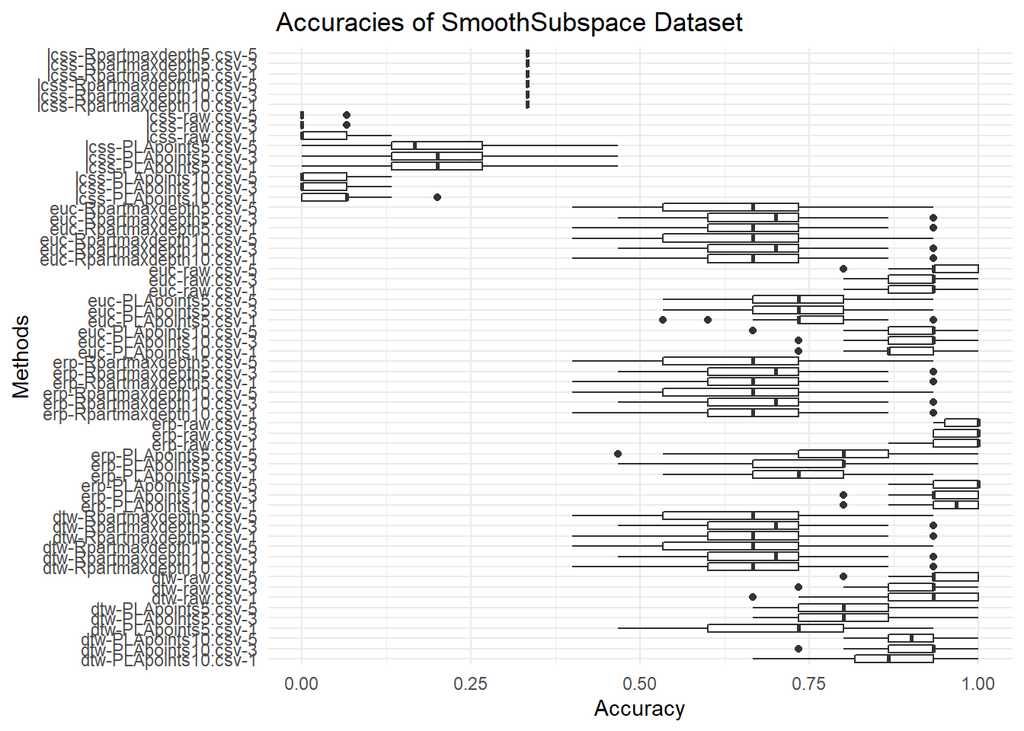

```r
SMOOTHSUBSPACE[[2]]
```

```
##            dataset                 rep approach k     avg_acc   sdev_acc
##  1: SmoothSubspace             raw.csv     lcss 5 0.004000000 0.01599320
##  2: SmoothSubspace             raw.csv     lcss 3 0.006666667 0.02020305
##  3: SmoothSubspace             raw.csv     lcss 1 0.025333333 0.04015842
##  4: SmoothSubspace     PLApoints10.csv     lcss 5 0.026666667 0.03809524
##  5: SmoothSubspace     PLApoints10.csv     lcss 3 0.036000000 0.04706343
##  6: SmoothSubspace     PLApoints10.csv     lcss 1 0.060000000 0.05259696
##  7: SmoothSubspace      PLApoints5.csv     lcss 5 0.180000000 0.09735737
##  8: SmoothSubspace      PLApoints5.csv     lcss 3 0.208000000 0.09955912
##  9: SmoothSubspace      PLApoints5.csv     lcss 1 0.214666667 0.11451564
## 10: SmoothSubspace Rpartmaxdepth10.csv     lcss 1 0.333333333 0.00000000
## 11: SmoothSubspace Rpartmaxdepth10.csv     lcss 3 0.333333333 0.00000000
## 12: SmoothSubspace Rpartmaxdepth10.csv     lcss 5 0.333333333 0.00000000
## 13: SmoothSubspace  Rpartmaxdepth5.csv     lcss 1 0.333333333 0.00000000
## 14: SmoothSubspace  Rpartmaxdepth5.csv     lcss 3 0.333333333 0.00000000
```

[output cut: 109 more lines]

### Prediction of Dataset 4: Smooth Subspace

The maximum average accuracy and low std is given by erp distance calculations 5-nn classifier method by using raw data time series, therefore the predictions based on this method.

```r
# data readed and merge to use train data as predictor of TEST data
SmoothSubspace_train_data <- as.data.table( read.table("SmoothSubspace\\SmoothSubspace_TRAIN.txt"))
dim(SmoothSubspace_train_data)
```

```
## [1] 150  16
```

```r
SmoothSubspace_test_data <- as.data.table( read.table("SmoothSubspace\\SmoothSubspace_TEST.txt"))
dim(SmoothSubspace_test_data)
```

```
## [1] 150  16
```

```r
SmoothSubspace_data <- rbind(SmoothSubspace_train_data,SmoothSubspace_test_data)
SmoothSubspace_data[,id := 1:.N]
dim(SmoothSubspace_data)
```

```
## [1] 300  17
```

```r
SmoothSubspace_matrix <- SmoothSubspace_data[, 2:(ncol(SmoothSubspace_data)-1)]
SmoothSubspace_class <- as.factor(SmoothSubspace_data$V1)

# the distance calculations basen on erp
#dist_mat=as.matrix(TSDatabaseDistances(SmoothSubspace_matrix,distance='erp',g=0.5))
#diag(dist_mat)=  2*max(dist_mat)
#fwrite(dist_mat,'SmoothSubspace/TEST.csv',col.names=F)

dist_matrix <-as.matrix(fread("D:\\Users\\seyma\\Documents\\GitHub\\fall21-seymacakir\\HW3\\SmoothSubspace\\TEST.csv",header=FALSE))

#the predictions based on 5-nn classifier
SmoothSubspace_TEST_prediction <- as.factor(nn_classify_cv(dist_matrix,SmoothSubspace_class,test_indices = c(151:300), k=5)$prediction$predicted)

# Confusion Matrix shown
confusionMatrix(data = SmoothSubspace_TEST_prediction, reference = SmoothSubspace_class[151:300])
```

```
## Confusion Matrix and Statistics
##
##           Reference
## Prediction  1  2  3
##          1 49  0  0
##          2  0 50  0
##          3  1  0 50
##
## Overall Statistics
##
##                Accuracy : 0.9933
##                  95% CI : (0.9634, 0.9998)
##     No Information Rate : 0.3333
##     P-Value [Acc > NIR] : < 2.2e-16
##
##                   Kappa : 0.99
##
##  Mcnemar's Test P-Value : NA
##
## Statistics by Class:
##
##                      Class: 1 Class: 2 Class: 3
## Sensitivity            0.9800   1.0000   1.0000
## Specificity            1.0000   1.0000   0.9900
## Pos Pred Value         1.0000   1.0000   0.9804
## Neg Pred Value         0.9901   1.0000   1.0000
## Prevalence             0.3333   0.3333   0.3333
## Detection Rate         0.3267   0.3333   0.3333
## Detection Prevalence   0.3267   0.3333   0.3400
## Balanced Accuracy      0.9900   1.0000   0.9950
```

```r
SmoothSubspace_test_acc = confusionMatrix(SmoothSubspace_TEST_prediction, reference = SmoothSubspace_class[151:300])$overall["Accuracy"]
```

## Dataset 5: PowerCons

The data used as PowerCons provided by [Time Series Classification Website](http://www.timeseriesclassification.com/description.php?Dataset=PowerCons) explained dataset below:

The PowerCons dataset contains the individual household electric power consumption in one year distributed in two season classes: warm (class 1) and cold (class 2), depending on whether the power consumption is recorded during the warm seasons (from April to September) or the cold seasons (from October to March). Note that the electric power consumption profiles differ markedly within classes. The sampling rate is every ten-minute over a period of one year. Number of classes: 2 - Class 1: Warm season - Class 2: Cold season Missing value: No Source: EDF R&D, Clamart, France

The example of data shown below. Data is proceed to first column indicates class and last column indicates id of time series. Other columns shows the observations during the time.

```r
### PowerCons DATA SET ###
# the data pre-proceed
PowerCons_raw_data <- raw_data_preperation("PowerCons")
```

```
##    class   V2   V3   V4   V5   V6   V7   V8   V9  V10  V11  V12  V13  V14  V15
## 1:     1 0.44 0.40 0.36 0.35 0.35 0.38 0.36 0.35 0.35 0.38 0.38 0.38 0.42 0.45
## 2:     1 0.14 0.19 0.19 0.16 0.16 0.18 0.17 0.16 0.17 0.17 0.16 0.18 0.18 0.14
## 3:     1 0.34 0.34 0.34 0.26 0.18 0.83 1.48 1.36 0.95 0.55 0.42 0.29 0.26 0.24
## 4:     1 1.70 1.50 1.30 3.40 5.50 4.15 2.80 2.67 2.53 2.49 2.45 2.41 1.64 0.88
## 5:     1 1.78 1.59 1.39 1.45 1.45 1.41 1.40 1.45 1.46 1.40 0.85 0.30 0.34 0.38
## 6:     1 0.41 0.30 0.24 0.28 0.28 0.28 0.23 0.25 0.31 0.31 0.26 0.24 0.30 0.35
##     V16  V17  V18  V19  V20  V21  V22  V23  V24  V25  V26  V27  V28  V29  V30
## 1: 0.43 0.37 0.66 1.13 1.35 1.09 0.75 0.41 0.37 0.33 0.33 0.40 0.40 0.39 0.40
## 2: 0.13 0.16 0.19 0.14 0.15 0.18 0.18 0.15 0.16 0.19 0.17 0.16 0.16 0.17 0.16
## 3: 0.24 0.25 0.23 0.25 0.26 0.25 0.25 0.26 0.28 0.30 0.33 0.31 0.30 0.27 0.25
## 4: 0.53 0.19 0.17 0.16 0.16 0.22 0.29 0.19 0.14 0.15 0.21 0.26 0.26 0.22 0.21
## 5: 0.33 0.33 0.39 0.35 0.31 0.31 0.35 0.38 0.38 0.33 0.33 0.38 0.39 0.35 0.33
## 6: 0.36 0.33 0.33 0.37 0.36 0.29 0.27 0.29 0.31 0.28 0.26 0.28 0.29 0.29 0.27
##     V31  V32  V33  V34  V35  V36  V37  V38  V39  V40  V41  V42  V43  V44  V45
```

[output cut: 55 more lines]

```r
# distances calculated
#get_distances(PowerCons_raw_data$traindata,PowerCons_raw_data$distpath, "PowerCons","raw")
```

The graph below shows the time series by classes.

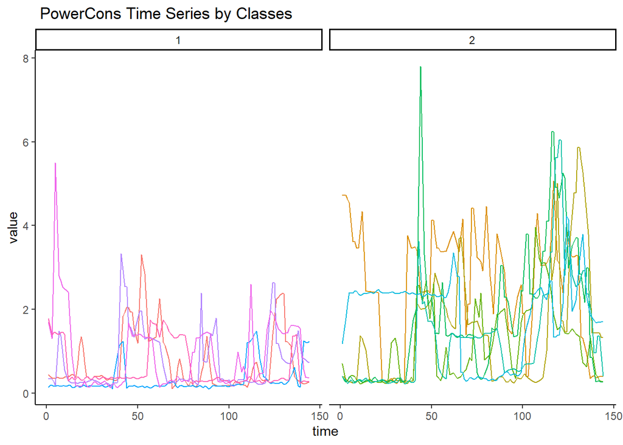

```r
g1(PowerCons_raw_data$raw_data[c(1:5,175:180)], "PowerCons")
```

### Classification with Time Series Representation

**Piece Linear Approximation method set points parameter = 5**

```r
# Data representation and preparation
PowerCons_pla_rep_5 <- pla_rep_data("PowerCons",5 ,PowerCons_raw_data$raw_data)
# Distance Calculated
#get_distances(PowerCons_pla_rep_5$traindata,PowerCons_raw_data$distpath,"PowerCons","PLApoints5")
```

**Piece Linear Approximation method set points parameter = 10**

```r
# Data representation and preparation
PowerCons_pla_rep_10 <- pla_rep_data("PowerCons", 10,PowerCons_raw_data$raw_data)
# Distance Calculated
#get_distances(PowerCons_pla_rep_10$traindata, PowerCons_raw_data$distpath,"PowerCons","PLApoints10")
```

**Rpart Regression Tree Representation set max depth paramater = 5**

```r
# Data representation and preparation
PowerCons_rpart_5 <- rpart_rep_data("PowerCons", 5 ,PowerCons_raw_data$raw_data)
# Distance calculated
#get_distances(PowerCons_rpart_5$traindata,PowerCons_raw_data$distpath,"PowerCons","Rpartmaxdepth5")
```

**Rpart Regression Tree Representation set max depth paramater = 10**

```r
# Data representation and preparation
PowerCons_rpart_10 <- rpart_rep_data("PowerCons", 10, PowerCons_raw_data$raw_data)
# Distance Calculated
#get_distances(PowerCons_rpart_10$traindata,PowerCons_raw_data$distpath,"PowerCons","Rpartmaxdepth10")
```

### Results of Methods

The Accuracy Values calculted and shown below.

```r
PowerCons_Results <- get_acc(PowerCons_raw_data$distpath,5,10,c(1,3,5),PowerCons_raw_data$trainclass)
POWERCONS <- show_results(PowerCons_Results,"PowerCons")
```

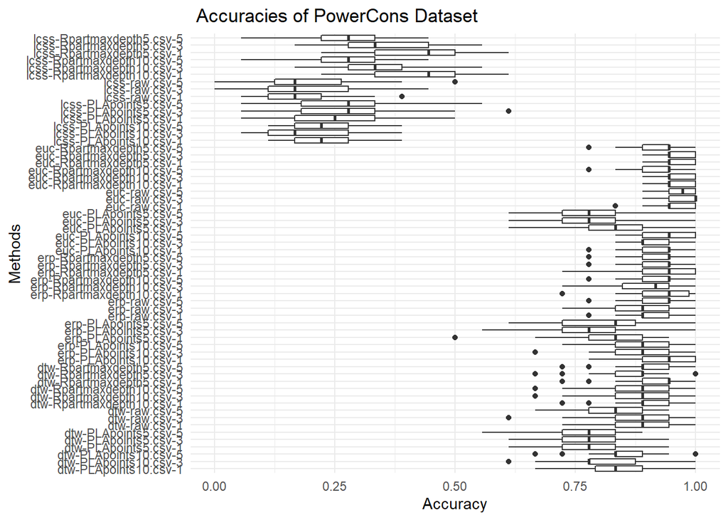

```r
POWERCONS[[2]]
```

```
##       dataset                 rep approach k   avg_acc   sdev_acc result_count
##  1: PowerCons     PLApoints10.csv     lcss 3 0.1911111 0.08559663           50
##  2: PowerCons             raw.csv     lcss 1 0.1922222 0.08993853           50
##  3: PowerCons             raw.csv     lcss 3 0.1955556 0.10362539           50
##  4: PowerCons             raw.csv     lcss 5 0.1988889 0.09661048           50
##  5: PowerCons     PLApoints10.csv     lcss 1 0.2333333 0.07694730           50
##  6: PowerCons     PLApoints10.csv     lcss 5 0.2388889 0.07956324           50
##  7: PowerCons Rpartmaxdepth10.csv     lcss 5 0.2611111 0.09407357           50
##  8: PowerCons      PLApoints5.csv     lcss 1 0.2611111 0.09991808           50
##  9: PowerCons      PLApoints5.csv     lcss 3 0.2700000 0.11556275           50
## 10: PowerCons  Rpartmaxdepth5.csv     lcss 5 0.2711111 0.09696841           50
## 11: PowerCons      PLApoints5.csv     lcss 5 0.2711111 0.10264823           50
## 12: PowerCons Rpartmaxdepth10.csv     lcss 3 0.3366667 0.10064669           50
## 13: PowerCons  Rpartmaxdepth5.csv     lcss 3 0.3522222 0.10385005           50
## 14: PowerCons Rpartmaxdepth10.csv     lcss 1 0.4133333 0.10418311           50
```

[output cut: 47 more lines]

### Prediciton of Dataset 5: PowerCons

The euclidian distance with 3-nn classifier gives the best rsult based on raw data time series. The class of test data predicted basen on this method.

```r
# data readed and merge to use train data as predictor of TEST data
PowerCons_train_data <- as.data.table( read.table("PowerCons\\PowerCons_TRAIN.txt"))
dim(PowerCons_train_data)
```

```
## [1] 180 145
```

```r
PowerCons_test_data <- as.data.table( read.table("PowerCons\\PowerCons_TEST.txt"))
dim(PowerCons_test_data)
```

```
## [1] 180 145
```

```r
PowerCons_data <- rbind(PowerCons_train_data,PowerCons_test_data)
PowerCons_data[,id := 1:.N]
dim(PowerCons_data)
```

```
## [1] 360 146
```

```r
PowerCons_matrix <- PowerCons_data[, 2:(ncol(PowerCons_data)-1)]
PowerCons_class <- as.factor(PowerCons_data$V1)

# Distance calculates based on euclidiean distance

#dist_mat=as.matrix(dist(PowerCons_matrix))
#diag(dist_mat)=  2*max(dist_mat)
#fwrite(dist_mat,'PowerCons/TEST.csv',col.names=F)

dist_matrix <-as.matrix(fread("D:\\Users\\seyma\\Documents\\GitHub\\fall21-seymacakir\\HW3\\PowerCons\\TEST.csv",header=FALSE))

# predictions based on 3-nn classifier
PowerCons_TEST_prediction <- as.factor(nn_classify_cv(dist_matrix,PowerCons_class,test_indices = c(181:360), k=3)$prediction$predicted)

# Confudion Matrix shown
confusionMatrix(data = PowerCons_TEST_prediction, reference = PowerCons_class[181:360])
```

```
## Confusion Matrix and Statistics
##
##           Reference
## Prediction  1  2
##          1 88  4
##          2  2 86
##
##                Accuracy : 0.9667
##                  95% CI : (0.9289, 0.9877)
##     No Information Rate : 0.5
##     P-Value [Acc > NIR] : <2e-16
##
##                   Kappa : 0.9333
##
##  Mcnemar's Test P-Value : 0.6831
##
##             Sensitivity : 0.9778
##             Specificity : 0.9556
##          Pos Pred Value : 0.9565
##          Neg Pred Value : 0.9773
##              Prevalence : 0.5000
##          Detection Rate : 0.4889
##    Detection Prevalence : 0.5111
##       Balanced Accuracy : 0.9667
##
##        'Positive' Class : 1
##
```

```r
PowerCons_test_acc <- confusionMatrix(data = PowerCons_TEST_prediction, reference = PowerCons_class[181:360])$overall["Accuracy"]
```

## Overall Results

The Overall results of accuracies of train data and test data by the best method in train dataset is shown below:

```r
RESULTS = rbind(TRACE[[1]], ECG200[[1]],PLANE[[1]][5],SMOOTHSUBSPACE[[1]],POWERCONS[[1]])[,1:5]
RESULTS[, test_acc:= c(Trace_test_acc,ECG_test_acc,Plane_test_acc,SmoothSubspace_test_acc,PowerCons_test_acc)]
setnames(RESULTS,"avg_acc","cv_train_acc")
RESULTS
```

```
##           dataset     rep approach k cv_train_acc  test_acc
## 1:          Trace raw.csv      dtw 1    1.0000000 0.9900000
## 2:         ECG200 raw.csv      euc 3    0.9040000 0.9000000
## 3:          Plane raw.csv      erp 3    1.0000000 0.9904762
## 4: SmoothSubspace raw.csv      erp 5    0.9826667 0.9933333
## 5:      PowerCons raw.csv      euc 3    0.9711111 0.9666667
```

The overall observation, the distance approach and nn classifier differs for datasets but the representation methods not give best results for all of them.

## Code of Study

The code of my study is available from [here](https://bu-ie-48B.github.io/fall21-seymacakir/HW3/HW3.R)